# Week 3 Project

## Gretchen Greene

Compiled on Wed Mar 29 21:29:12 2017.

—-Figure 1….

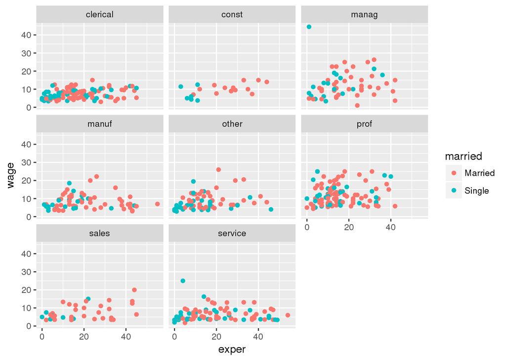

```r
ggplot(data = CPS85, aes(x = exper, y = wage, color = married)) + geom_point() + facet_wrap( ~ sector)
```

What mode of graphic is it? A scatter plot

What variables from the respective data tables are involved? The variables involved are experience, Wage, married, sector

What role each of those variables plays in the graphic? The x-axis is exper level, wage is the y variable, the graphic is faceted by sector, and it is colored by married or not

Figure 2

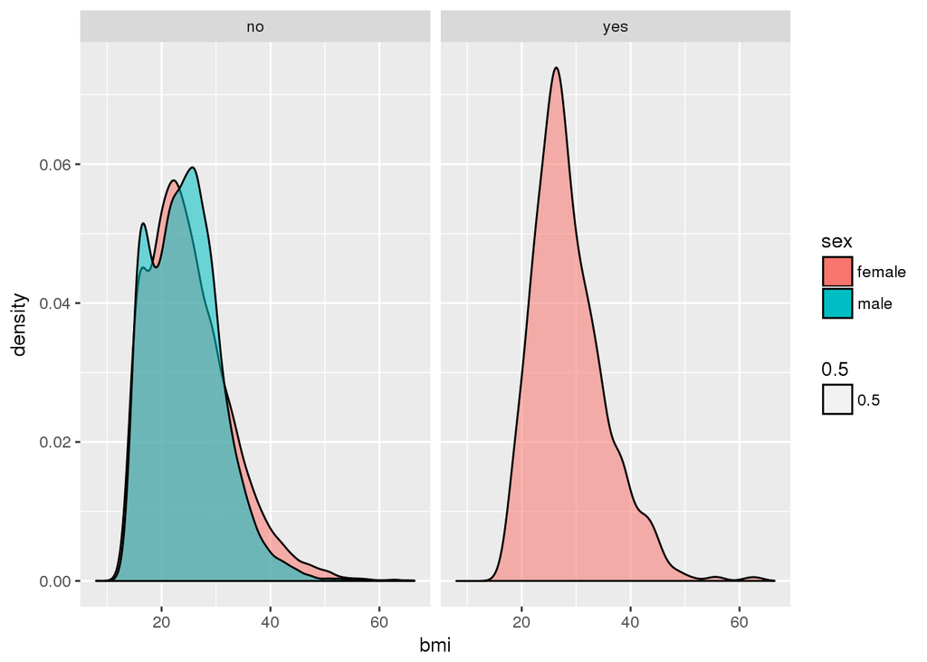

```r
ggplot(data = NCHS, aes(x = bmi)) + geom_density(aes(fill = sex, alpha= 0.5)) + facet_wrap(~pregnant)
```

What mode of graphic is it? Figure 2 is a density plot

What variables from the respective data tables are involved? The variables involved are density, bmi, sex, and pregnant or not.

In Figure 2, why is there no data variable being used for the y-axis? There is no variable becuase it is a density plot. Density is the y axis.

Wrangling

```r
help("diamonds")
```

1. Which color diamonds seem to be largest on avergage?

```r
diamonds%>%
  group_by(color)%>%
  summarize(size = mean(carat)) %>%
  arrange(desc(size))%>%
  head(1)
```

```
## # A tibble: 1 × 2
##   color     size
##   <ord>    <dbl>
## 1     J 1.162137
```

2. Which clarity of diamonds has the largest average “table” per carat?

```r
diamonds%>%
  group_by(clarity)%>%
  summarize(avgtable=mean(table))%>%
  arrange(desc(avgtable))%>%
  head(1)
```

```
## # A tibble: 1 × 2
##   clarity avgtable
##     <ord>    <dbl>
## 1      I1 58.30378
```

11 has the largest avgtable of 58.30378

Voting:

```r
Minneapolis2013 %>% nrow()
```

```
## [1] 80101
```

1. 80101 cases

```r
Minneapolis2013 %>%
  group_by(Second) %>%
  summarise(votes=n()) %>%
  arrange(desc(votes)) %>%
  head(5)
```

```
## # A tibble: 5 × 2
##               Second votes
##                <chr> <int>
## 1       BETSY HODGES 14399
## 2        DON SAMUELS 14170
## 3        MARK ANDREW 12757
## 4          undervote 10598
## 5 JACKIE CHERRYHOMES  6470
```

2. The top 5 canidates in the second vote selesctions were: Betsy Hodges, Don Samuels, Mark Andrew, undervote, Jackie Cherryhomes

```r
Minneapolis2013 %>%
  filter(First =='undervote')%>%
  tally()
```

```
##     n
## 1 834
```

```r
Minneapolis2013 %>%
  filter(Second == 'undervote') %>%
  tally()
```

```
##       n
## 1 10598
```

```r
Minneapolis2013 %>%
  filter(Third == 'undervote') %>%
  tally()
```

```
##       n
## 1 19210
```

3. 1. 834 undervotes in first choice
2. 10598 undervotes in second choice
3. 19210 undervotes in third choice

```r
Minneapolis2013 %>%
  filter(First=='BETSY HODGES') %>%
  group_by(Second)%>%
  summarise(votes=n())%>%
  arrange(desc(votes))%>%
  head(3)
```

```
## # A tibble: 3 × 2
##               Second votes
##                <chr> <int>
## 1        MARK ANDREW  8787
## 2        DON SAMUELS  8743
## 3 JACKIE CHERRYHOMES  2563
```

4. top 3 second vote selesctions among people who voted for Betsy Hodges: 1. Mark Andrew: 8787 votes, 2. Don Samuels: 8743 votes, 3. Jackie Cherryhomes: 2563 votes

```r
Minneapolis2013 %>%
  group_by(Precinct) %>%
  summarise(fraction = base::mean(First=='undervote')) %>%
  arrange(desc(fraction))%>%
  head(1)
```

```
## # A tibble: 1 × 2
##   Precinct   fraction
##      <chr>      <dbl>
## 1     P-6C 0.07738095
```

5. Precinct P-6C had the highest fraction of First vote selections marked as “undervote”.